# Data Analysis

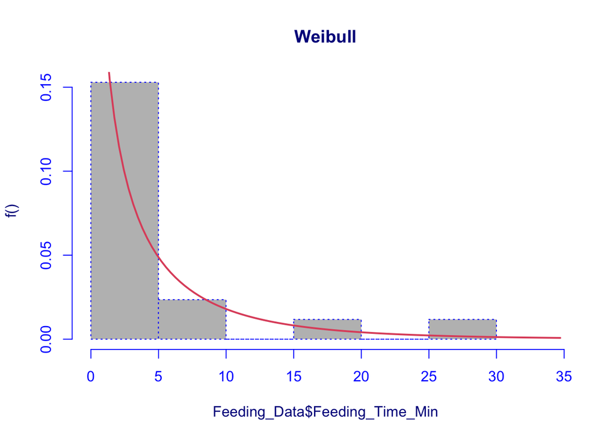

```r
Green_Weibull <- histDist(Feeding_Data$Feeding_Time_Min, "WEI",
                          density = F, main = "Weibull") #AIC = 115.143
```

**Running model:** We are going to use the lnorm distribution because the p value is larger and AIC value is smaller.

```r
Feeding_Data$orderTreatment = ordered(Feeding_Data$Treatment,
                                      levels = c("Control", "25C", "30C"))

Feeding_lNorm_model <- gamlss(formula = Feeding_Time_Min ~ Date*Treatment +
                                random(Species_ID) + random(Field_Site) +
                                random(Acclimation_Period),
                              family = LOGNO(), data = Feeding_Data,
                              control = gamlss.control(n.cyc = 3))
```

```
## GAMLSS-RS iteration 1: Global Deviance = 60.3695
## GAMLSS-RS iteration 2: Global Deviance = 60.3691
```

```r
summary(Feeding_lNorm_model) # significance is only in post-heat 30C
```

```
## Family:  c("LOGNO", "Log Normal")
##
## Call:  gamlss(formula = Feeding_Time_Min ~ Date * Treatment +
##     random(Species_ID) + random(Field_Site) + random(Acclimation_Period),
##     family = LOGNO(), data = Feeding_Data, control = gamlss.control(n.cyc = 3))
##
##
## Fitting method: RS()
##
## ------------------------------------------------------------------
## Mu link function:  identity
## Mu Coefficients:
##                            Estimate Std. Error t value Pr(>|t|)
## (Intercept)                 -0.5298     0.5149  -1.029   0.3330
## Date11/9/2021               -0.2449     0.7281  -0.336   0.7451
## Treatment25C                 0.8233     0.8141   1.011   0.3409
## Treatment30C                 0.3369     0.7281   0.463   0.6557
## Date11/9/2021:Treatment25C   1.9684     1.1513   1.710   0.1249
## Date11/9/2021:Treatment30C   2.3532     0.9970   2.360   0.0453 *
## ---
## Signif. codes:  0 '***' 0.001 '**' 0.01 '*' 0.05 '.' 0.1 ' ' 1
##
## ------------------------------------------------------------------
## Sigma link function:  log
## Sigma Coefficients:
##             Estimate Std. Error t value Pr(>|t|)
## (Intercept)  -0.1145     0.1715  -0.668    0.523
##
## ------------------------------------------------------------------
## NOTE: Additive smoothing terms exist in the formulas:
##  i) Std. Error for smoothers are for the linear effect only.
## ii) Std. Error for the linear terms maybe are not accurate.
## ------------------------------------------------------------------
## No. of observations in the fit:  17
## Degrees of Freedom for the fit:  8.831933
##       Residual Deg. of Freedom:  8.168067
##                       at cycle:  2
##
## Global Deviance:     60.36911
##             AIC:     78.03298
##             SBC:     85.39186
```

**Table 4**: Feeding data, using gamlss with Log Normal distribution. Significance compared to pre-heat of control.

[output not shown]

**Plot for Feeding:** Box plot with event on the x axis and feeding time on the y axix, colours represent different treatments.

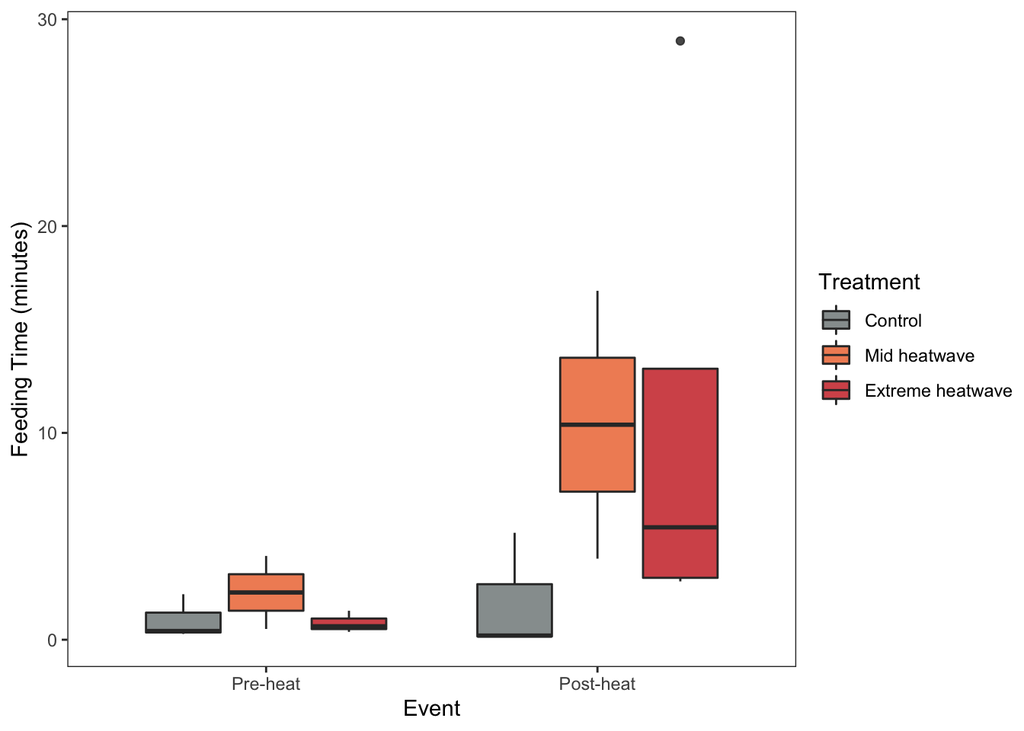

```r
feeding_plot <- ggplot(Feeding_Data, aes(x = Date, y = Feeding_Time_Min, fill = Treatment)) +
  geom_boxplot(alpha=0.85) +
  xlab("Event") +
  ylab("Feeding Time (minutes)") +
  scale_fill_manual(limits = c("Control", "25C", "30C"),
                    labels = c("Control", "Mid heatwave", "Extreme heatwave"),
                    values = cols_for_heat) +
  theme_test()
feeding_plot <- feeding_plot +
  scale_x_discrete(labels=c("11/5/2021" = "Pre-heat", "11/9/2021" = "Post-heat"))
feeding_plot
```

```r
ggsave(here("./images/feeding_plot.png"), feeding_plot)
```

## Heat Data

Includes temperature during heatwave and behavioral responses (open vs closed)

```r
# Data reorganization, adding average temp at each hour
heat_data <- heat_data %>%
  mutate(Open_Closed = as.factor(Open_Closed), Bucket = as.factor(Bucket),
         Treatment = as.factor(Treatment), Field_Site = as.factor(Field_Site)) %>%
  mutate(Open_Closed = fct_relevel(Open_Closed, "Open", "Partial", "Closed")) %>%
  mutate(Treatment = fct_relevel(Treatment, "Control", "25C", "30C")) %>%
  group_by(Treatment, Time_Block) %>%
  mutate(Temp_avg = mean(Bucket_Temp))
```

**Temperature over Time Graph:** Line plot with time in hours on the x axis and temperature on the y axis, colours represent different treatments.

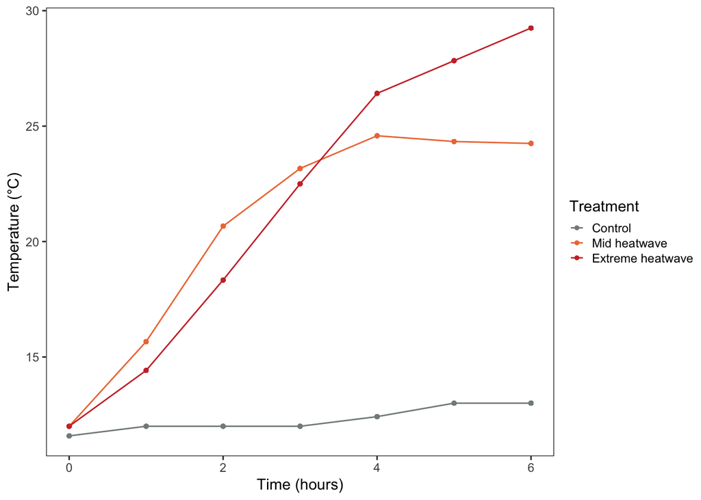

```r
heat_plot <- ggplot(data = heat_data, aes(x = Time_Block, y = Temp_avg, color = Treatment)) +
  geom_point(size = 1) +
  geom_line(alpha = 1.5) +
  xlab("Time (hours)") +
  ylab("Temperature (°C)") +
  scale_colour_manual(limits = c("Control", "25C", "30C"),
                    labels = c("Control", "Mid heatwave", "Extreme heatwave"),
                    values = cols_for_heat) +
  theme(axis.title.x = element_text(size=10),
        axis.title.y = element_text(size=10)) +
  theme_test()
heat_plot <- heat_plot + theme(legend.key.size = unit(0.75, 'lines'))
heat_plot
```

```r
ggsave(here("./images/heat_plot.png"), heat_plot)
```

### Ordinal Regression

Model to test significance on the open/partial/closed data.

```r
ord_model = clmm(Open_Closed ~ Treatment + (1 | Bucket) + (1 | Species_ID),
                 data = heat_data)
summary(ord_model) # significance in both treatments
```

```
## Cumulative Link Mixed Model fitted with the Laplace approximation
##
## formula: Open_Closed ~ Treatment + (1 | Bucket) + (1 | Species_ID)
## data:    heat_data
##
##  link  threshold nobs logLik  AIC     niter    max.grad cond.H
##  logit flexible  756  -682.12 1376.25 220(930) 2.31e-05 1.1e+02
##
## Random effects:
##  Groups     Name        Variance  Std.Dev.
##  Species_ID (Intercept) 1.069e+00 1.034e+00
##  Bucket     (Intercept) 1.190e-11 3.450e-06
## Number of groups:  Species_ID 36,  Bucket 12
##
## Coefficients:
##              Estimate Std. Error z value Pr(>|z|)
## Treatment25C   2.0438     0.4768   4.286 1.82e-05 ***
## Treatment30C   1.9778     0.4777   4.140 3.47e-05 ***
## ---
## Signif. codes:  0 '***' 0.001 '**' 0.01 '*' 0.05 '.' 0.1 ' ' 1
##
## Threshold coefficients:
##                Estimate Std. Error z value
## Open|Partial     1.3765     0.3492   3.941
## Partial|Closed   2.9049     0.3613   8.040
```

**Open/Closed Graph:** Stacked bar plot with time in hours during heatwave on the x axis and frequency count on the y axis> The 3 bar plots are separated by treatment and the colours indicate different behaviours.

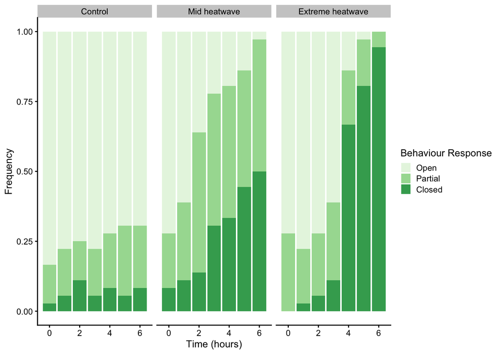

```r
behaviour_data <- heat_data %>%
  group_by(Day, Treatment, Time_Block) %>%
  count(Open_Closed)

behaviour_plot <- ggplot(data = behaviour_data, aes(x = Time_Block, y = n, fill = Open_Closed)) +
  geom_bar(alpha = 0.95, position="fill", stat="identity") +
  facet_grid(. ~ Treatment,
             labeller = labeller(Treatment = treatment_labels)) +
  xlab("Time (hours)") +
  ylab("Frequency") +
  scale_fill_brewer(palette = "Greens") +
  theme_cowplot(10)
behaviour_plot <- behaviour_plot + labs(fill = "Behaviour Response")
behaviour_plot
```

```r
ggsave(here("./images/behaviour_plot.png"), behaviour_plot, width = 10, height = 6)
```